# Homework 4

Samantha Rabinowitz, sar4357

5/13/2020

# Preliminaries

Included in the R Markdown file but hidden from view to limit the length of this document is the loading of the following packages necessary to use the functions utilized in this assignment: *tidyverse*, *patchwork*, *scales*, *collapse*, *BBmisc*, *devtools*, and *tidycovid19*. Additionally, the code used to write the **cv_summary** function and organization of the data file included in the *tidycovid19* package are also not included in this final knit document.

# Challenge 1

```r
cv_summary(cv_data)
```

```
## $totals
## # A tibble: 6 x 8
##   country variable          cases population      area density   rate on
##   <chr>   <chr>             <dbl>      <dbl>     <dbl>   <dbl>  <dbl> <date>
## 1 World   confirmed       4100108 7523799801    1.27e8    59.4 545.   2020-05-10
## 2 World   daily_confirmed   99113 7523799801    1.27e8    59.4  13.2  2020-05-10
## 3 World   daily_deaths       8856 7523799801    1.27e8    59.4   1.18 2020-05-10
## 4 World   daily_recovered   65439 7523799801    1.27e8    59.4   8.70 2020-05-10
## 5 World   deaths           282666 7523799801    1.27e8    59.4  37.6  2020-05-10
## 6 World   recovered       1407676 7523799801    1.27e8    59.4 187.   2020-05-10
##
## $cum_cases_plot
```

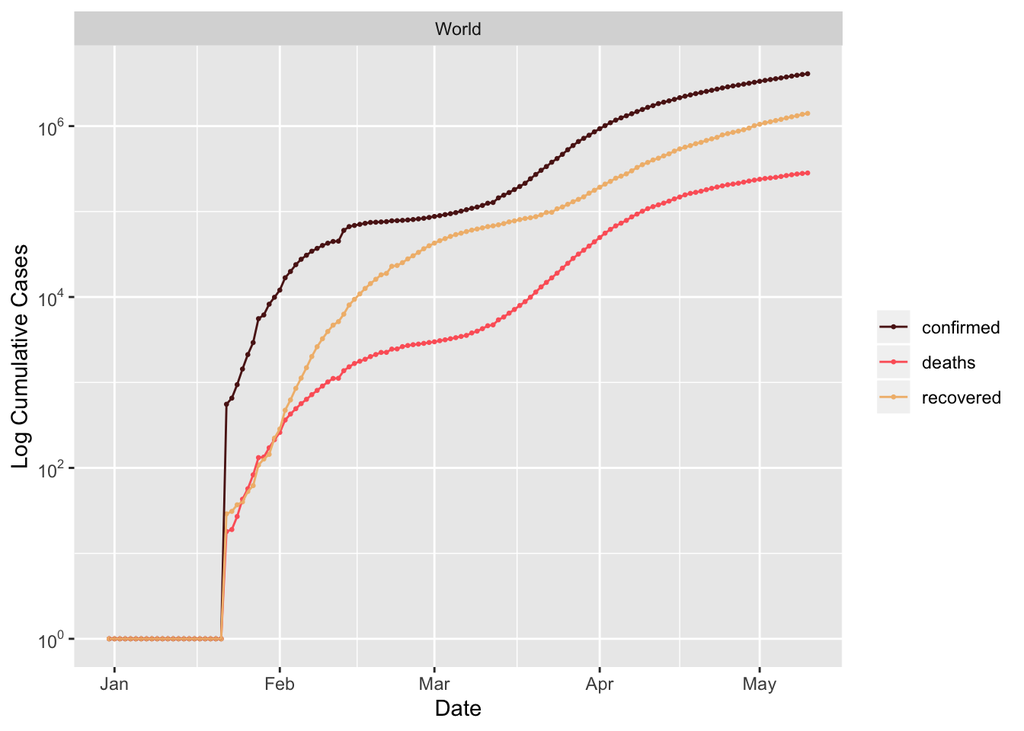

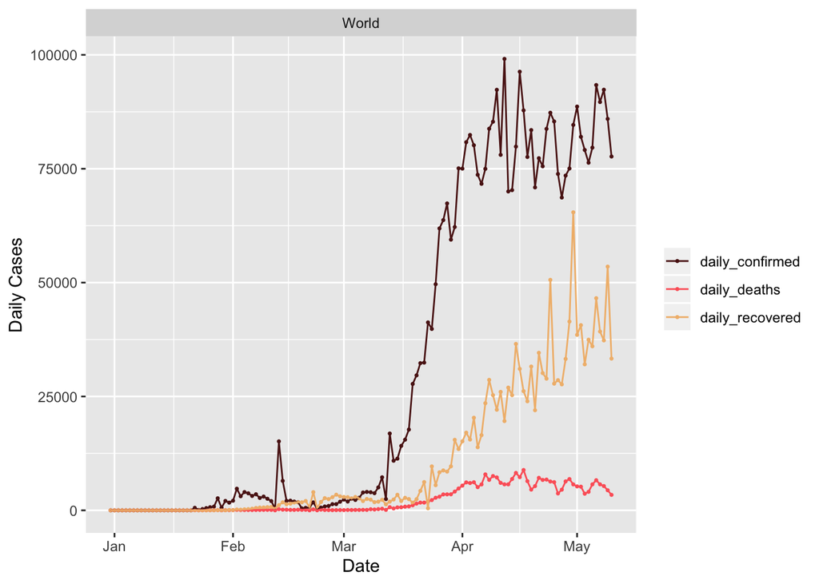

# Challenge 2

```r
cv_summary(cv_data, country_list = c("United States", "United Kingdom", "Canada", "France", "Italy", "Japan", "China", "Russia", "Iran"))
```

```
## $totals
## # A tibble: 54 x 13
##    country variable cases population   area density    rate gdp_capita income
##    <chr>   <chr>    <dbl>      <dbl>  <dbl>   <dbl>   <dbl>      <dbl> <chr>
##  1 Canada  confirm… 70091   37057765 9.09e6    4.08 1.89e+3     51392. High …
##  2 Canada  daily_c…  2778   37057765 9.09e6    4.08 7.50e+1     51392. High …
##  3 Canada  daily_d…   251   37057765 9.09e6    4.08 6.77e+0     51392. High …
##  4 Canada  daily_r…  1385   37057765 9.09e6    4.08 3.74e+1     51392. High …
##  5 Canada  deaths    4991   37057765 9.09e6    4.08 1.35e+2     51392. High …
##  6 Canada  recover… 32109   37057765 9.09e6    4.08 8.66e+2     51392. High …
##  7 China   confirm… 84010 1392730000 9.39e6  148.   6.03e+1      7753. Upper…
##  8 China   daily_c… 15136 1392730000 9.39e6  148.   1.09e+1      7753. Upper…
##  9 China   daily_d…  1290 1392730000 9.39e6  148.   9.26e-1      7753. Upper…
## 10 China   daily_r…  3995 1392730000 9.39e6  148.   2.87e+0      7753. Upper…
## # … with 44 more rows, and 4 more variables: life_expectancy <dbl>,
## #   max_sd <dbl>, max_mr <dbl>, on <date>
##
## $cum_cases_plot
```

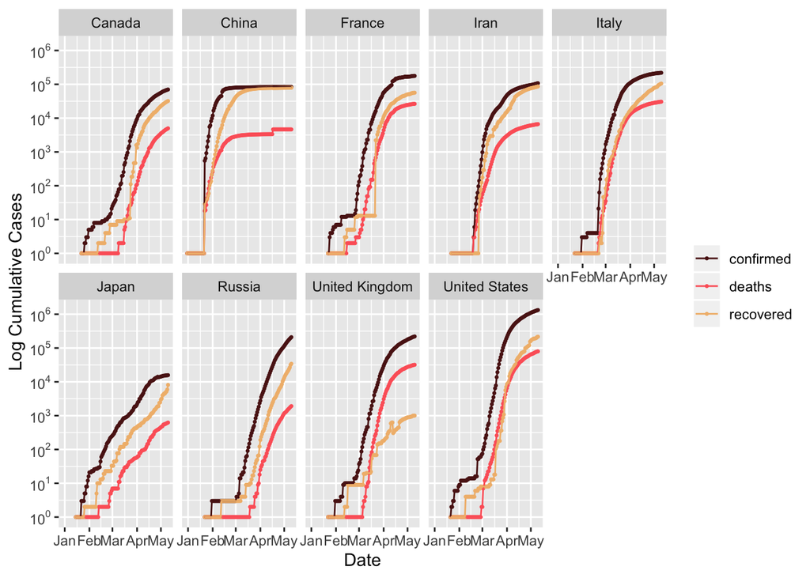

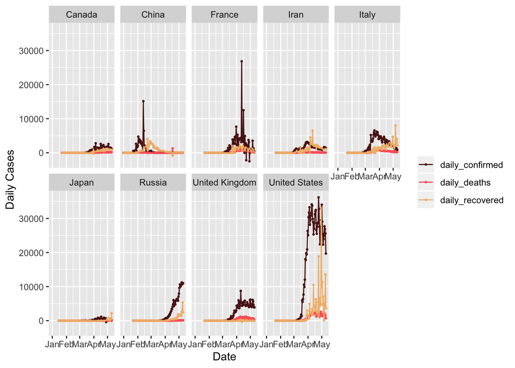

```r
cv_summary(cv_data, country_list = c("United States", "United Kingdom", "Canada", "France", "Italy", "Japan", "China", "Russia", "Iran"), facet = "variable")
```

```
## $totals
## # A tibble: 54 x 13
##    country variable cases population   area density    rate gdp_capita income
##    <chr>   <chr>    <dbl>      <dbl>  <dbl>   <dbl>   <dbl>      <dbl> <chr>
##  1 Canada  confirm… 70091   37057765 9.09e6    4.08 1.89e+3     51392. High …
##  2 Canada  daily_c…  2778   37057765 9.09e6    4.08 7.50e+1     51392. High …
##  3 Canada  daily_d…   251   37057765 9.09e6    4.08 6.77e+0     51392. High …
##  4 Canada  daily_r…  1385   37057765 9.09e6    4.08 3.74e+1     51392. High …
##  5 Canada  deaths    4991   37057765 9.09e6    4.08 1.35e+2     51392. High …
##  6 Canada  recover… 32109   37057765 9.09e6    4.08 8.66e+2     51392. High …
##  7 China   confirm… 84010 1392730000 9.39e6  148.   6.03e+1      7753. Upper…
##  8 China   daily_c… 15136 1392730000 9.39e6  148.   1.09e+1      7753. Upper…
##  9 China   daily_d…  1290 1392730000 9.39e6  148.   9.26e-1      7753. Upper…
## 10 China   daily_r…  3995 1392730000 9.39e6  148.   2.87e+0      7753. Upper…
## # … with 44 more rows, and 4 more variables: life_expectancy <dbl>,
## #   max_sd <dbl>, max_mr <dbl>, on <date>
##
## $cum_cases_plot
```

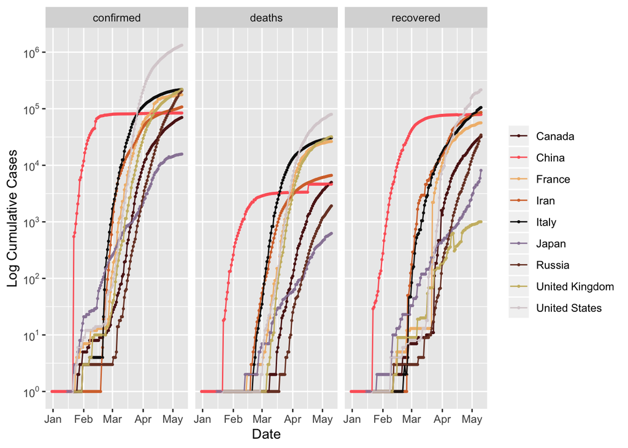

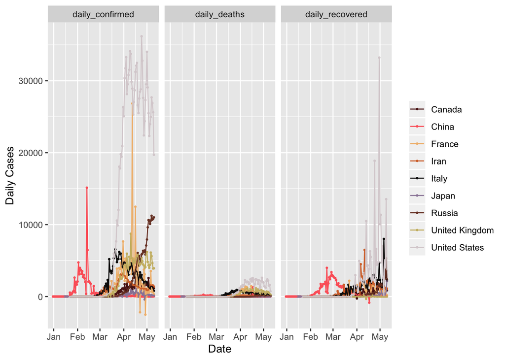

# Challenge 3

```r
(d <- cv_data %>% filter(population > 1000000) %>% cv_summary(country_list = "All", plot = FALSE))
```

```
## $totals
## # A tibble: 924 x 13
##    country variable cases population   area density    rate gdp_capita income
##    <chr>   <chr>    <dbl>      <dbl>  <dbl>   <dbl>   <dbl>      <dbl> <chr>
##  1 Afghan… confirm…  4402   37172386 652860    56.9 118.          564. Low i…
##  2 Afghan… daily_c…   369   37172386 652860    56.9   9.93        564. Low i…
##  3 Afghan… daily_d…    13   37172386 652860    56.9   0.350       564. Low i…
##  4 Afghan… daily_r…    56   37172386 652860    56.9   1.51        564. Low i…
##  5 Afghan… deaths     120   37172386 652860    56.9   3.23        564. Low i…
##  6 Afghan… recover…   558   37172386 652860    56.9  15.0         564. Low i…
##  7 Albania confirm…   868    2866376  27400   105.  303.         5079. Upper…
##  8 Albania daily_c…    34    2866376  27400   105.   11.9        5079. Upper…
##  9 Albania daily_d…     4    2866376  27400   105.    1.40       5079. Upper…
## 10 Albania daily_r…    31    2866376  27400   105.   10.8        5079. Upper…
## # … with 914 more rows, and 4 more variables: life_expectancy <dbl>,
## #   max_sd <dbl>, max_mr <dbl>, on <date>
```

# Challenge 4

```r
(overall <- d$totals %>% filter(variable == "confirmed") %>% arrange(desc(rate)))
```

```
## # A tibble: 154 x 13
##    country variable  cases population   area density  rate gdp_capita income
##    <chr>   <chr>     <dbl>      <dbl>  <dbl>   <dbl> <dbl>      <dbl> <chr>
##  1 Qatar   confirm… 2.25e4    2781677 1.16e4   240.  8096.     63261. High …
##  2 Spain   confirm… 2.24e5   46796540 5.00e5    93.5 4794.     32950. High …
##  3 Ireland confirm… 2.30e4    4867309 6.89e4    70.5 4725.     76881. High …
##  4 Belgium confirm… 5.31e4   11433256 3.03e4   377.  4643.     47166. High …
##  5 Singap… confirm… 2.33e4    5638676 7.09e2  7953.  4139.     58248. High …
##  6 United… confirm… 1.33e6  326687501 9.15e6    35.8 4069.     54579. High …
##  7 Italy   confirm… 2.19e5   60421760 2.94e5   205.  3626.     35432. High …
##  8 Switze… confirm… 3.03e4    8513227 3.95e4   216.  3560.     79214. High …
##  9 United… confirm… 2.20e5   66460344 2.42e5   275.  3317.     43325. High …
## 10 Bahrain confirm… 4.94e3    1569439 7.78e2  2017.  3148.     21438. High …
## # … with 144 more rows, and 4 more variables: life_expectancy <dbl>,
## #   max_sd <dbl>, max_mr <dbl>, on <date>
```

```r
(daily <- d$totals %>% filter(variable=="daily_confirmed") %>% arrange(desc(rate)))
```

```
## # A tibble: 154 x 13
##    country variable cases population   area density  rate gdp_capita income
##    <chr>   <chr>    <dbl>      <dbl>  <dbl>   <dbl> <dbl>      <dbl> <chr>
##  1 Ecuador daily_c… 11536   17084357 2.48e5    68.8  675.      5185. Upper…
##  2 Qatar   daily_c…  1311    2781677 1.16e4   240.   471.     63261. High …
##  3 France  daily_c… 26849   66977107 5.48e5   122.   401.     43664. High …
##  4 Ireland daily_c…  1515    4867309 6.89e4    70.5  311.     76881. High …
##  5 Kuwait  daily_c…  1065    4137309 1.78e4   232.   257.     33112. High …
##  6 Singap… daily_c…  1426    5638676 7.09e2  7953.   253.     58248. High …
##  7 Belgium daily_c…  2454   11433256 3.03e4   377.   215.     47166. High …
##  8 Bahrain daily_c…   330    1569439 7.78e2  2017.   210.     21438. High …
##  9 Spain   daily_c…  9630   46796540 5.00e5    93.5  206.     32950. High …
## 10 Belarus daily_c…  1485    9483499 2.03e5    46.7  157.      6744. Upper…
## # … with 144 more rows, and 4 more variables: life_expectancy <dbl>,
## #   max_sd <dbl>, max_mr <dbl>, on <date>
```

The 10 countries with the highest overall rate of confirmed cases are Qatar, Spain, Ireland, Belgium, Singapore, United States, Italy, Switzerland, United Kingdom, and Bahrain.

The 10 countries with the highest single day rate of confirmed cases are Ecuador, Qatar, France, Ireland, Kuwait, Singapore, Belgium, Bahrain, Spain, and Belarus.

# Challenge 5

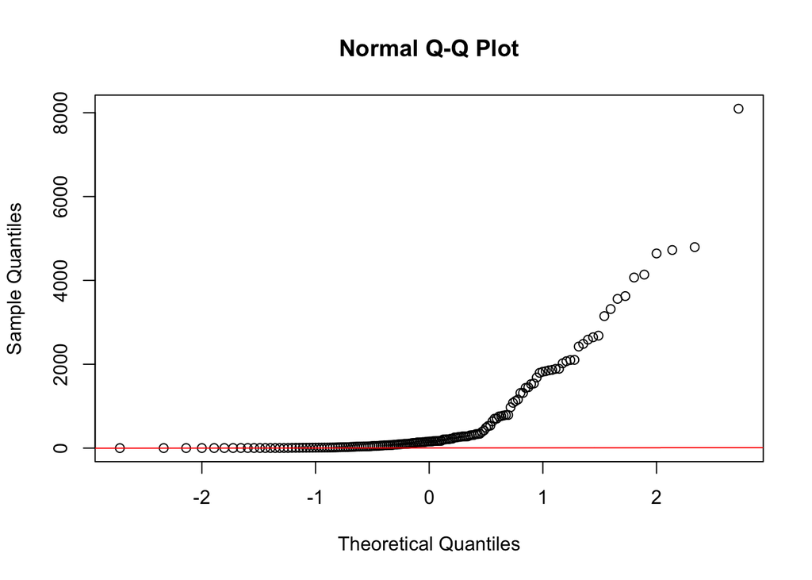

```r
qqnorm(overall$rate); qqline(log(overall$rate), col = 'red')
```

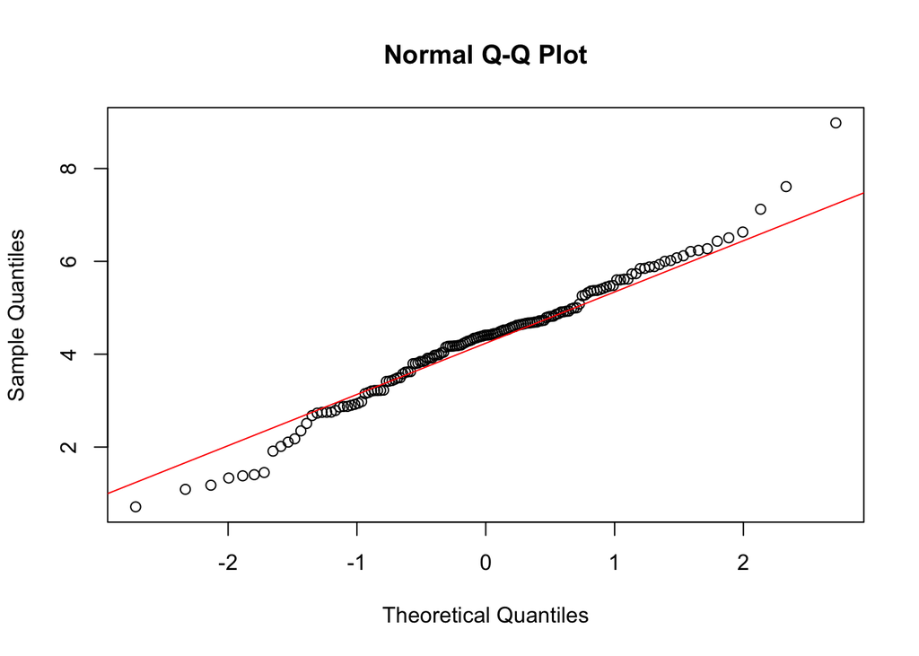

```r
qqnorm(log(overall$density)); qqline(log(overall$density), col = 'red')
```

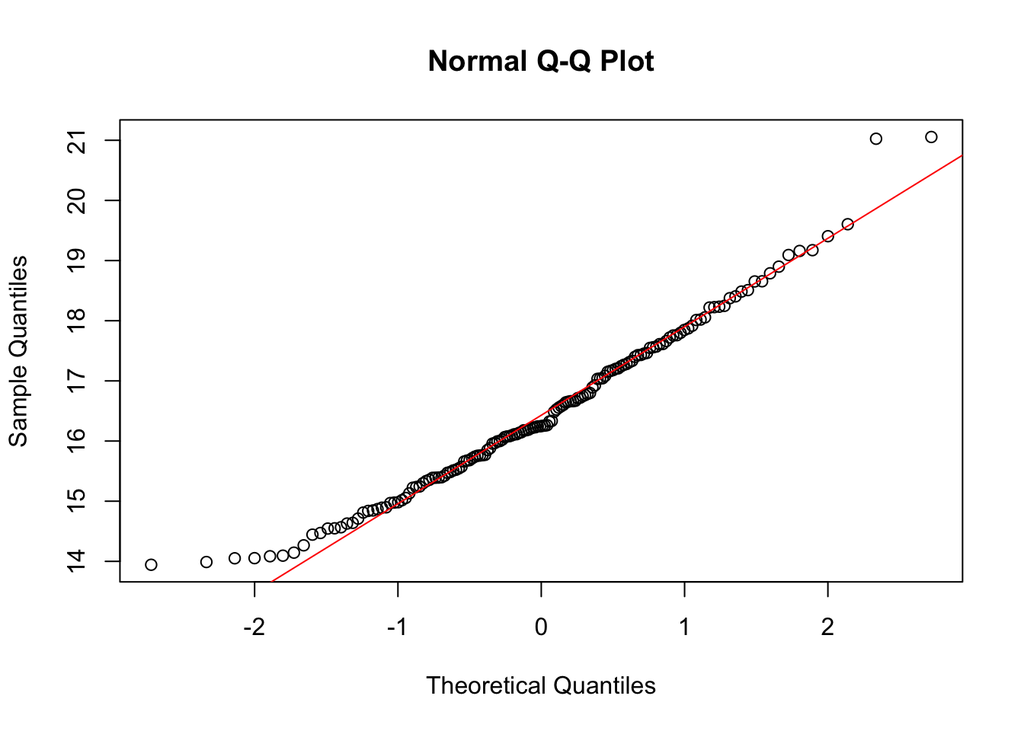

```r
qqnorm(log(overall$population)); qqline(log(overall$population), col = 'red')
```

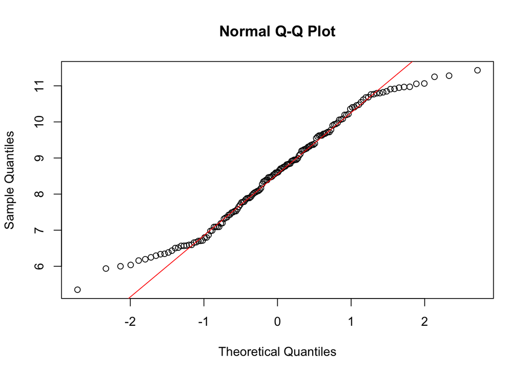

```r
qqnorm(log(overall$gdp_capita)); qqline(log(overall$gdp_capita), col = 'red')
```

```r
model <- lm(rate ~ log(density) + log(population) + log(gdp_capita) + income, data = overall)
summary(model)
```

```
##
## Call:
## lm(formula = rate ~ log(density) + log(population) + log(gdp_capita) +
##     income, data = overall)
##
## Residuals:
##     Min      1Q  Median      3Q     Max
## -2283.8  -434.4   -83.5   275.9  5558.7
##
## Coefficients:
##                            Estimate Std. Error t value Pr(>|t|)
## (Intercept)               -7541.172   1942.390  -3.882 0.000157 ***
## log(density)                146.445     58.610   2.499 0.013599 *
## log(population)               7.878     55.386   0.142 0.887091
## log(gdp_capita)             828.494    175.729   4.715 5.69e-06 ***
## incomeLow income           1487.992    732.611   2.031 0.044100 *
## incomeLower middle income   533.413    524.470   1.017 0.310847
## incomeUpper middle income    -9.521    337.264  -0.028 0.977519
## ---
## Signif. codes:  0 '***' 0.001 '**' 0.01 '*' 0.05 '.' 0.1 ' ' 1
##
## Residual standard error: 926.4 on 143 degrees of freedom
##   (4 observations deleted due to missingness)
## Multiple R-squared:  0.4712, Adjusted R-squared:  0.449
## F-statistic: 21.24 on 6 and 143 DF,  p-value: < 2.2e-16
```

In the model above, the predictor variables with slopes significantly different from 0 are population density, GDP per capita, and Low overall income level.

# Challenge 6

```r
library(MASS)
library(MuMIn)


(s <- stepAIC(model, scope = . ~ ., direction = "both"))
```

```
## Start:  AIC=2056.24
## rate ~ log(density) + log(population) + log(gdp_capita) + income
##
##                   Df Sum of Sq       RSS    AIC
## - log(population)  1     17365 122755251 2054.3
## <none>                         122737886 2056.2
## - log(density)     1   5358582 128096468 2060.7
## - income           3  13604811 136342697 2066.0
## - log(gdp_capita)  1  19077988 141815874 2075.9
##
## Step:  AIC=2054.26
## rate ~ log(density) + log(gdp_capita) + income
##
##                   Df Sum of Sq       RSS    AIC
## <none>                         122755251 2054.3
## + log(population)  1     17365 122737886 2056.2
## - log(density)     1   5532996 128288247 2058.9
## - income           3  13589391 136344642 2064.0
## - log(gdp_capita)  1  19562541 142317792 2074.4
```

```
##
## Call:
## lm(formula = rate ~ log(density) + log(gdp_capita) + income,
##     data = overall)
##
## Coefficients:
##               (Intercept)               log(density)
##                -7453.2511                   147.5339
##           log(gdp_capita)           incomeLow income
##                  831.7594                  1504.4648
## incomeLower middle income  incomeUpper middle income
##                  548.4831                    -0.9716
```

```r
summary(s)
```

```
##
## Call:
## lm(formula = rate ~ log(density) + log(gdp_capita) + income,
##     data = overall)
##
## Residuals:
##     Min      1Q  Median      3Q     Max
## -2266.3  -436.8   -74.5   275.6  5545.6
##
## Coefficients:
##                             Estimate Std. Error t value Pr(>|t|)
## (Intercept)               -7453.2511  1835.1391  -4.061 7.98e-05 ***
## log(density)                147.5339    57.9096   2.548   0.0119 *
## log(gdp_capita)             831.7594   173.6296   4.790 4.09e-06 ***
## incomeLow income           1504.4648   720.9341   2.087   0.0387 *
## incomeLower middle income   548.4831   511.9069   1.071   0.2858
## incomeUpper middle income    -0.9716   330.7347  -0.003   0.9977
## ---
## Signif. codes:  0 '***' 0.001 '**' 0.01 '*' 0.05 '.' 0.1 ' ' 1
##
## Residual standard error: 923.3 on 144 degrees of freedom
##   (4 observations deleted due to missingness)
## Multiple R-squared:  0.4711, Adjusted R-squared:  0.4527
## F-statistic: 25.65 on 5 and 144 DF,  p-value: < 2.2e-16
```

```r
r.squaredGLMM(s)
```

```
##            R2m       R2c
## [1,] 0.4626137 0.4626137
```

```r
r.squaredGLMM(model)
```

```
##            R2m       R2c
## [1,] 0.4609563 0.4609563
```

```r
daily_model <- lm(rate ~ log(density) + log(population) + log(gdp_capita) + income, data = daily)

(s_daily <- stepAIC(daily_model, scope = . ~ ., direction = "both"))
```

```
## Start:  AIC=1317.57
## rate ~ log(density) + log(population) + log(gdp_capita) + income
##
##                   Df Sum of Sq    RSS    AIC
## - income           3     19259 911124 1314.8
## - log(population)  1      4119 895983 1316.3
## <none>                         891865 1317.6
## - log(density)     1     26109 917974 1319.9
## - log(gdp_capita)  1     40396 932260 1322.2
##
## Step:  AIC=1314.77
## rate ~ log(density) + log(population) + log(gdp_capita)
##
##                   Df Sum of Sq     RSS    AIC
## - log(population)  1      5077  916200 1313.6
## <none>                          911124 1314.8
## - log(density)     1     28932  940055 1317.5
## + income           3     19259  891865 1317.6
## - log(gdp_capita)  1    223451 1134575 1345.7
##
## Step:  AIC=1313.6
## rate ~ log(density) + log(gdp_capita)
##
##                   Df Sum of Sq     RSS    AIC
## <none>                          916200 1313.6
## + log(population)  1      5077  911124 1314.8
## - log(density)     1     26609  942809 1315.9
## + income           3     20217  895983 1316.3
## - log(gdp_capita)  1    234216 1150417 1345.8
```

```
##
## Call:
## lm(formula = rate ~ log(density) + log(gdp_capita), data = daily)
##
## Coefficients:
##     (Intercept)     log(density)  log(gdp_capita)
##         -226.49            10.11            26.67
```

```r
summary(s_daily)
```

```
##
## Call:
## lm(formula = rate ~ log(density) + log(gdp_capita), data = daily)
##
## Residuals:
##     Min      1Q  Median      3Q     Max
## -111.46  -38.73  -12.48   15.61  630.82
##
## Coefficients:
##                 Estimate Std. Error t value Pr(>|t|)
## (Intercept)     -226.488     42.449  -5.335 3.53e-07 ***
## log(density)      10.108      4.892   2.066   0.0406 *
## log(gdp_capita)   26.672      4.351   6.130 7.69e-09 ***
## ---
## Signif. codes:  0 '***' 0.001 '**' 0.01 '*' 0.05 '.' 0.1 ' ' 1
##
## Residual standard error: 78.95 on 147 degrees of freedom
##   (4 observations deleted due to missingness)
## Multiple R-squared:  0.2276, Adjusted R-squared:  0.2171
## F-statistic: 21.66 on 2 and 147 DF,  p-value: 5.697e-09
```

Performing stepwise selection using AIC determined that a somewhat more nested model is the preferred model for predicting overall infection rate. This model contains the predictors log(density), log(gdp_capita), and income. The pseudo R2 value associated with the full model is 0.4610 and the value associated with the “best” model described above is 0.4626.

After using AIC to determine the preferred model for the maximum daily infection rate, it was revealed that the set of predictors that best describes rate in this model are only log(density) and log(gdp_capita). Income level is no longer a predictor determined to be important in this model.

# Challenge 7

```r
new_model <- lm(rate ~ log(density) + log(gdp_capita) + max_mr + max_sd, data = daily)
summary(new_model)
```

```
##
## Call:
## lm(formula = rate ~ log(density) + log(gdp_capita) + max_mr +
##     max_sd, data = daily)
##
## Residuals:
##     Min      1Q  Median      3Q     Max
## -114.84  -35.32  -13.40   14.51  636.67
##
## Coefficients:
##                  Estimate Std. Error t value Pr(>|t|)
## (Intercept)     -227.9227    42.4659  -5.367 3.13e-07 ***
## log(density)      11.0403     4.9290   2.240   0.0266 *
## log(gdp_capita)   26.9962     4.4704   6.039 1.26e-08 ***
## max_mr            -1.3934     0.8495  -1.640   0.1031
## max_sd             1.3978     1.4300   0.977   0.3300
## ---
## Signif. codes:  0 '***' 0.001 '**' 0.01 '*' 0.05 '.' 0.1 ' ' 1
##
## Residual standard error: 78.36 on 144 degrees of freedom
##   (5 observations deleted due to missingness)
## Multiple R-squared:  0.2532, Adjusted R-squared:  0.2325
## F-statistic: 12.21 on 4 and 144 DF,  p-value: 1.426e-08
```

```r
(s_new <- stepAIC(new_model, scope = . ~ ., direction = "both"))
```

```
## Start:  AIC=1304.59
## rate ~ log(density) + log(gdp_capita) + max_mr + max_sd
##
##                   Df Sum of Sq     RSS    AIC
## - max_sd           1      5866  890082 1303.6
## <none>                          884216 1304.6
## - max_mr           1     16521  900737 1305.3
## - log(density)     1     30806  915022 1307.7
## - log(gdp_capita)  1    223924 1108140 1336.2
##
## Step:  AIC=1303.57
## rate ~ log(density) + log(gdp_capita) + max_mr
##
##                   Df Sum of Sq     RSS    AIC
## <none>                          890082 1303.6
## - max_mr           1     14724  904806 1304.0
## + max_sd           1      5866  884216 1304.6
## - log(density)     1     33912  923994 1307.1
## - log(gdp_capita)  1    251950 1142032 1338.7
```

```
##
## Call:
## lm(formula = rate ~ log(density) + log(gdp_capita) + max_mr,
##     data = daily)
##
## Coefficients:
##     (Intercept)     log(density)  log(gdp_capita)           max_mr
##        -229.541           11.525           27.948           -1.308
```

```r
r.squaredGLMM(s_new)
```

```
##            R2m       R2c
## [1,] 0.2444556 0.2444556
```

```r
r.squaredGLMM(s_daily)
```

```
##            R2m       R2c
## [1,] 0.2252509 0.2252509
```

```r
detach(package:MASS)
detach(package:MuMIn)
```

As demonstrated by the stepwise selection using AIC above with a model containing the *max_sd* and *max_mr* variables added to the variables previously determined to be the most important predictors of maximum daily infection rate, adding *max_mr* to the model does result in a lower AIC (1303.57) as compared to the one generated using *log(density)* and *log(gdp_capita)* (1313.6). Additionally, the pseudo-R^2 values are also increased in the model using *max_mr* as an additional predictor variable (0.2253 in the model prior to adding the additional variable, 0.2445 in the model with the additional variable).

# Challenge 8

```r
library(lme4)
m1 <- lmer(data = cv_data, rate ~ log(density) + log(gdp_capita) + soc_dist + mov_rest + (1 | country) + (1 | date), REML=FALSE)
m2 <- lmer(data = cv_data, rate ~ log(density) + log(gdp_capita) + soc_dist + (1 | country) + (1 | date), REML=FALSE)
m3 <- lmer(data = cv_data, rate ~ log(density) + log(gdp_capita) + mov_rest + (1 | country) + (1 | date), REML=FALSE)
m4 <- lmer(data = cv_data, rate ~ log(density) + soc_dist + mov_rest + (1 | country) + (1 | date), REML=FALSE)
m5 <- lmer(data = cv_data, rate ~ log(gdp_capita) + soc_dist + mov_rest + (1 | country) + (1 | date), REML=FALSE)
m6 <- lmer(data = cv_data, rate ~ log(density) + log(gdp_capita) + (1 | country) + (1 | date), REML=FALSE)
m7 <- lmer(data = cv_data, rate ~ log(density) + soc_dist + (1 | country) + (1 | date), REML=FALSE)
m8 <- lmer(data = cv_data, rate ~ log(density) + mov_rest + (1 | country) + (1 | date), REML=FALSE)
m9 <- lmer(data = cv_data, rate ~ log(gdp_capita) + soc_dist + (1 | country) + (1 | date), REML=FALSE)
m10 <- lmer(data = cv_data, rate ~ log(gdp_capita) + mov_rest + (1 | country) + (1 | date), REML=FALSE)
m11 <- lmer(data = cv_data, rate ~ soc_dist + mov_rest + (1 | country) + (1 | date), REML=FALSE)
m12 <- lmer(data = cv_data, rate ~ log(density) + (1 | country) + (1 | date), REML=FALSE)
m13 <- lmer(data = cv_data, rate ~ log(gdp_capita) + (1 | country) + (1 | date), REML=FALSE)
m14 <- lmer(data = cv_data, rate ~ soc_dist + (1 | country) + (1 | date), REML=FALSE)
m15 <- lmer(data = cv_data, rate ~ mov_rest + (1 | country) + (1 | date), REML=FALSE)
null <- lmer(data = cv_data, rate ~ (1 | country) + (1 | date), REML=FALSE)

library(AICcmodavg)
(aic_table <- aictab(list(m1,m2,m3,m4,m5,m6,m7,m8,m9,m10,m11,m12,m13,m14,m15,null),
  modnames = c("m1","m2","m3","m4","m5","m6","m7","m8","m9","m10","m11","m12","m13","m14","m15","null")
))
```

```
##
## Model selection based on AICc:
##
##      K    AICc Delta_AICc AICcWt Cum.Wt        LL
## m1   8 1701511       0.00      1      1 -850747.4
## m3   7 1701674     163.56      0      1 -850830.2
## m2   7 1701683     172.28      0      1 -850834.6
## m5   7 1719636   18124.87      0      1 -859810.9
## m4   7 1719661   18149.99      0      1 -859823.4
## m10  6 1719796   18285.14      0      1 -859892.0
## m9   6 1719803   18292.49      0      1 -859895.7
## m8   6 1719835   18324.26      0      1 -859911.6
## m7   6 1719838   18326.96      0      1 -859912.9
## m11  6 1737773   36262.30      0      1 -868880.6
## m15  5 1737944   36433.15      0      1 -868967.0
## m14  5 1737945   36434.29      0      1 -868967.6
## m6   6 1789173   87661.89      0      1 -894580.4
## m13  5 1807502  105990.85      0      1 -903745.8
## m12  5 1845903  144392.42      0      1 -922946.6
## null 4 1864190  162679.64      0      1 -932091.2
```

```r
library(MuMIn)
r.squaredGLMM(m1)
```

```
##             R2m       R2c
## [1,] 0.03002423 0.1264869
```

After performing a set of mixed effects models, it was determined that the best model of the complete set that was run was the “full” model (called **m1** above). This model included 4 fixed effects (log(density), log(gdp_capita), soc_dist, and mov_rest) and 2 random effects (country and date). The pseudo R2 values associated with this model are 0.03 (marginal R2) and 0.126 (conditional R2).